```r
data <- c(2,2,4,6,4,5,2,3,1,2,0,4,3,3,3,3,4,2,7,2,4,3,3,3,4,3,7,5,3,1,7,6,4,6,5,2,4,7,2,2,6,2,4,5,4,5,1,3,2,3)

length(data)
```

```
## [1] 50
```

```r
summary(data)
```

```
##    Min. 1st Qu.  Median    Mean 3rd Qu.    Max.
##    0.00    2.00    3.00    3.56    4.75    7.00
```

```r
table(data)
```

```
## data
##  0  1  2  3  4  5  6  7
##  1  3 11 12 10  5  4  4
```

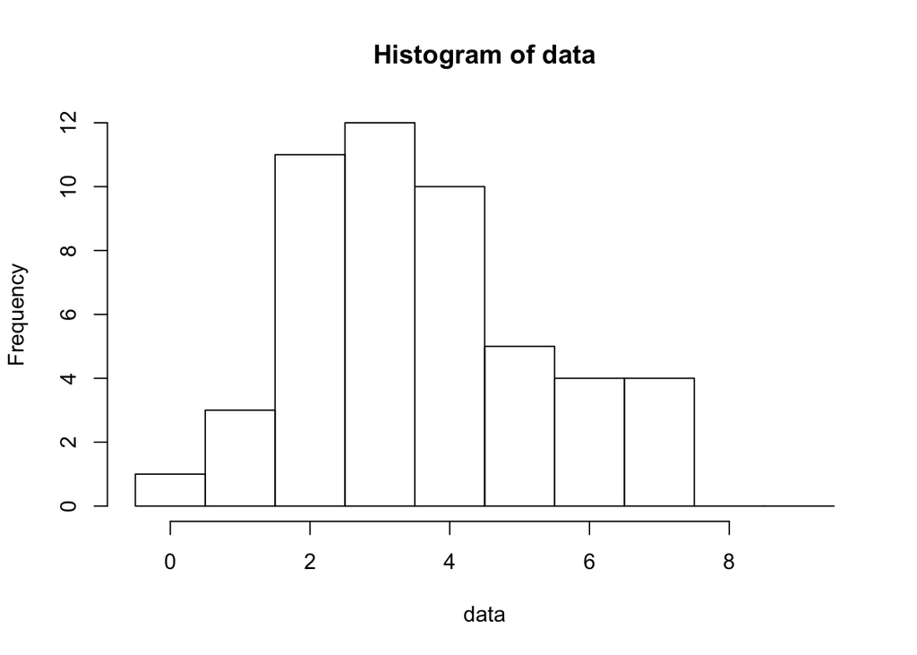

```r
hist(data,breaks = seq(-0.5,9.5,1))
```

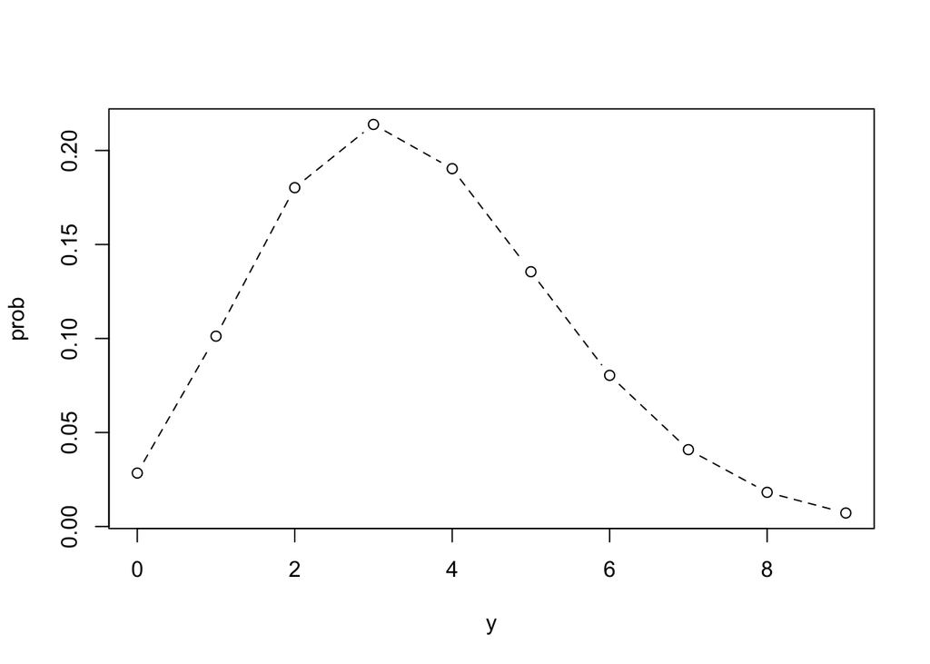

```r
y <- 0:9
prob <- dpois(y,lambda = 3.56)
plot(y,prob,type="b",lty=2)
```

この種子データにおいて、ポアソン分布が採択されたのは、

- データに含まれている値が非負の整数(カウントデータ)
- 下限はあるけど上限は不明
- 平均と分散が大体等しい

という理由による。

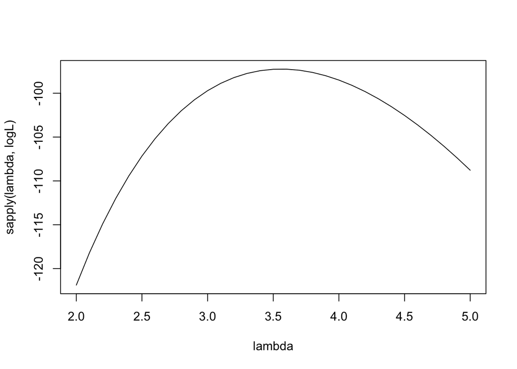

```r
logL <- function(m) sum(dpois(data,m,log=TRUE))
lambda <- seq(2,5,0.1)
plot(lambda,sapply(lambda,logL),type="l")
```

データ解析をする際に大事なのは、得られたデータからそれがどの様な分布に基づいているのかを推定し、 さらにそれを元にして予測を行うこと。 どの分布が良いのかを考えるにあたっては、

- 説明したい量は離散か連続か？
- 説明したい量の範囲は？
- 説明したい量の標本分散と標本平均の関係は？

この本ではカウントデータについては以下の2つを用いる

**ポアソン分布**

データが離散、ゼロ以上の範囲、上限特になし、平均と分散はほぼ等しい

**二項分布**

データが離散、ゼロ以上で有限の範囲、分散は平均の関数

連続に関しては6章あたりで出てくる

**正規分布**

データが連続、範囲は-∞ ~ ∞、分散は平均とは無関係に決まる

**ガンマ分布**

データが連続、範囲は0 ~ ∞、分散は平均の関数